# Titanic Survivors

DADS Club at Florida Polytechnic University

October 28, 2018

# Introduction

The purpose of this project was to predict who would have survived the Titanic. Input data included:

```
##  [1] "PassengerId" "Survived"    "Pclass"      "Name"        "Sex"
##  [6] "Age"         "SibSp"       "Parch"       "Ticket"      "Fare"
## [11] "Cabin"       "Embarked"
```

with Survived being the target variable.

#### Summary of Variables

**Survivel** : 1 for survivors 0 for victims. Factor  
**PassengerId** : Random ID number associated with a unique passenger  
**Pclass** : Ticket class (1, 2, 3)  
**Sex** : male or female  
**Parch** : Number of parents aboard  
**Age** : Age in years  
**Ticket** : Ticket number  
**Fare** : Fare for a passenger (assume it is in dollars)  
**Cabin** : The cabin number of the passenger  
**Embarked** : Port of embarkation (C = Cherbourg, Q = Queenstown, S = Southampton)

# Visualizations

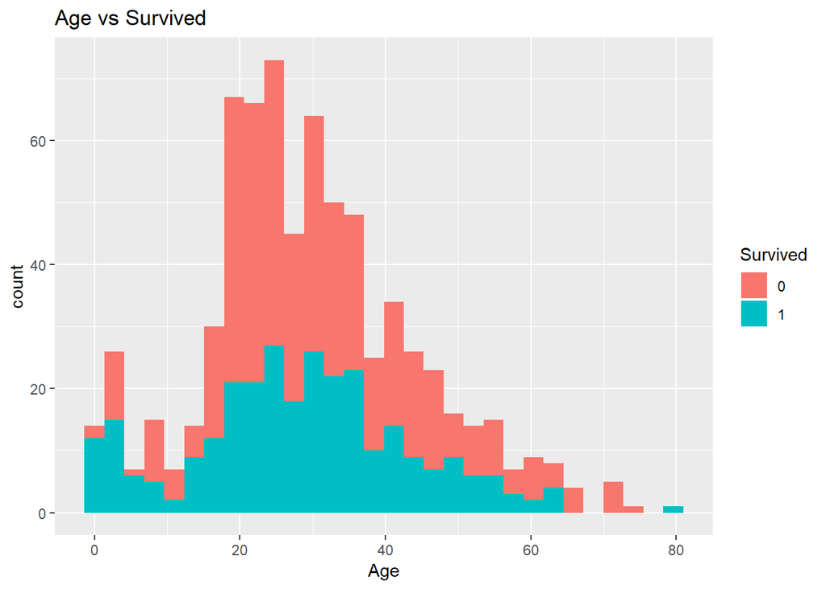

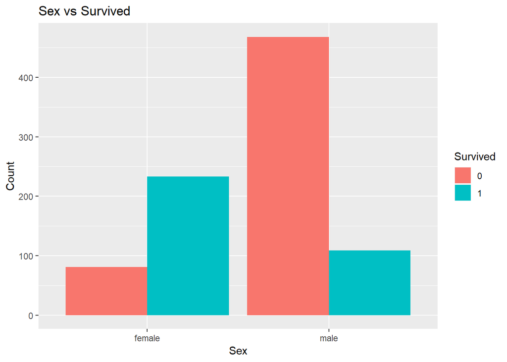

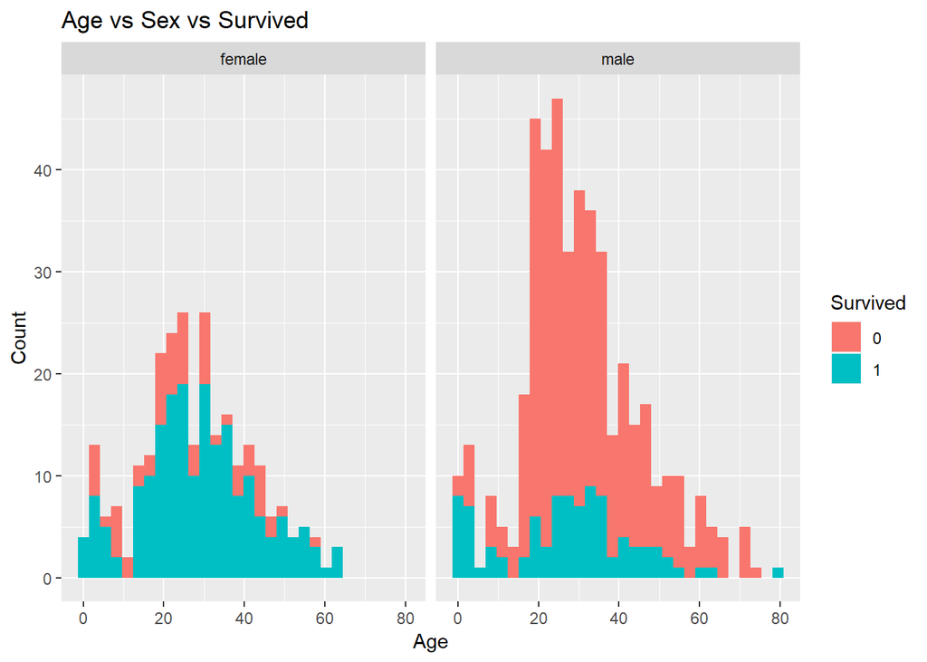

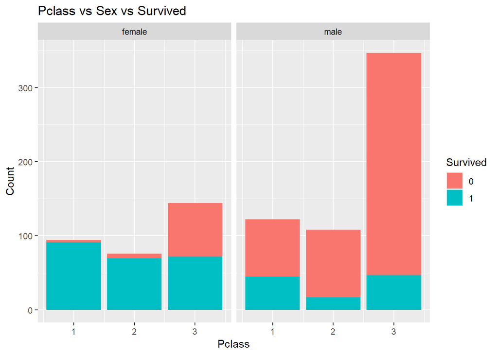

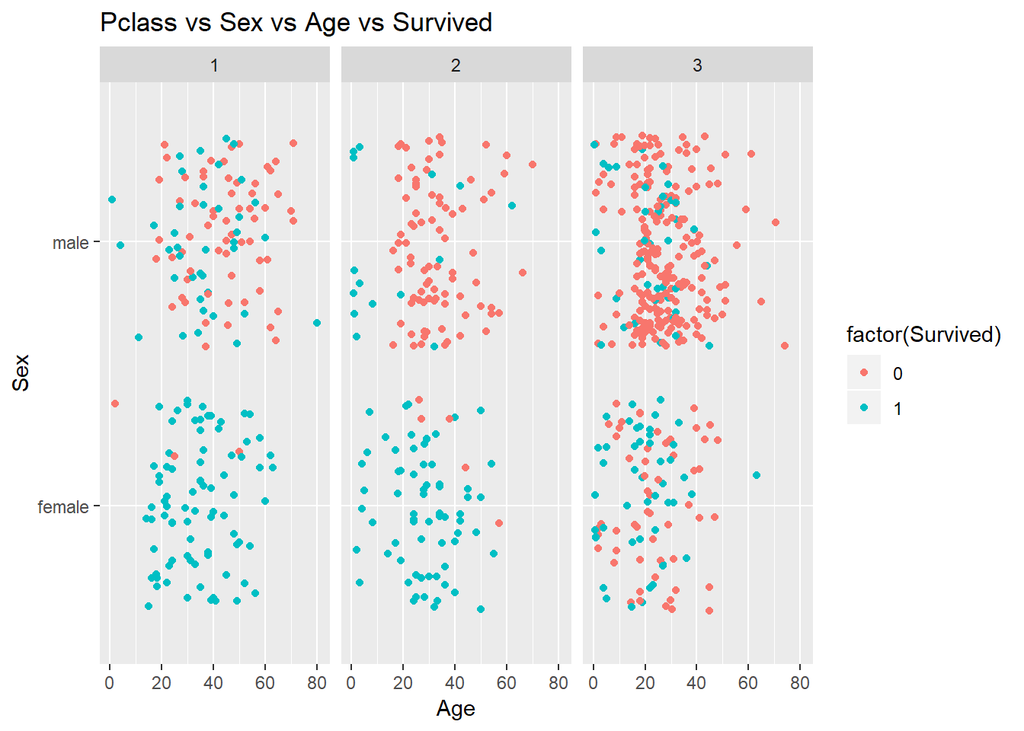

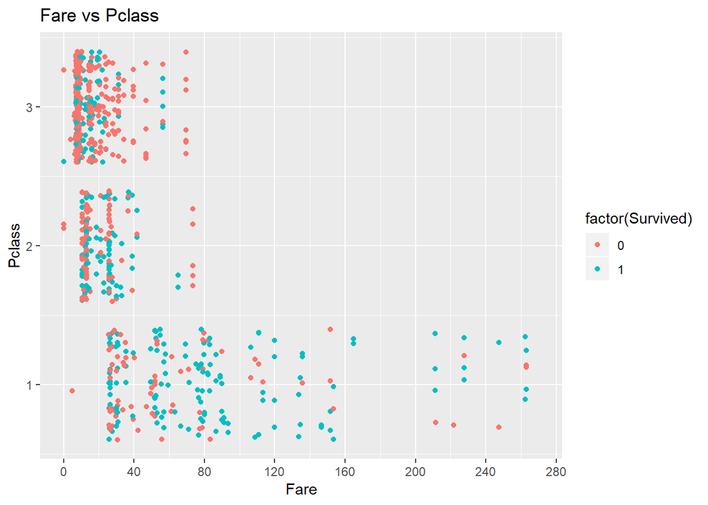

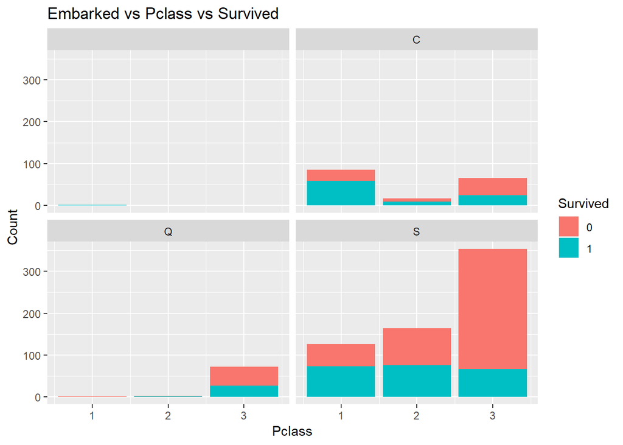